# Risk Factor Analysis

## Outcome Variable

**Outcome Variable:** stunted

## Predictor Variables

**Intervention Variable:** parity

**Adjustment Set:**

unadjusted

## Stratifying Variables

The analysis was stratified on these variable(s):

- agecat
- studyid
- country

## Data Summary

| agecat | studyid | country | A | n | nA | nAY0 | nAY1 |
| --- | --- | --- | --- | --- | --- | --- | --- |
| Birth | ki1101329-Keneba | GAMBIA | 1 | 1407 | 156 | 140 | 16 |
| Birth | ki1101329-Keneba | GAMBIA | 2 | 1407 | 146 | 138 | 8 |
| Birth | ki1101329-Keneba | GAMBIA | 3+ | 1407 | 1105 | 1054 | 51 |
| Birth | ki1126311-ZVITAMBO | ZIMBABWE | 1 | 13829 | 5972 | 5332 | 640 |
| Birth | ki1126311-ZVITAMBO | ZIMBABWE | 2 | 13829 | 4125 | 3718 | 407 |
| Birth | ki1126311-ZVITAMBO | ZIMBABWE | 3+ | 13829 | 3732 | 3347 | 385 |
| Birth | ki1135781-COHORTS | GUATEMALA | 1 | 407 | 57 | 54 | 3 |
| Birth | ki1135781-COHORTS | GUATEMALA | 2 | 407 | 70 | 66 | 4 |
| Birth | ki1135781-COHORTS | GUATEMALA | 3+ | 407 | 280 | 268 | 12 |
| Birth | ki1135781-COHORTS | INDIA | 1 | 4122 | 696 | 582 | 114 |
| Birth | ki1135781-COHORTS | INDIA | 2 | 4122 | 1037 | 939 | 98 |
| Birth | ki1135781-COHORTS | INDIA | 3+ | 4122 | 2389 | 2126 | 263 |
| Birth | ki1135781-COHORTS | PHILIPPINES | 1 | 3050 | 675 | 629 | 46 |
| Birth | ki1135781-COHORTS | PHILIPPINES | 2 | 3050 | 687 | 645 | 42 |
| Birth | ki1135781-COHORTS | PHILIPPINES | 3+ | 3050 | 1688 | 1589 | 99 |
| 3 months | ki1000304b-SAS-FoodSuppl | INDIA | 1 | 93 | 17 | 10 | 7 |
| 3 months | ki1000304b-SAS-FoodSuppl | INDIA | 2 | 93 | 19 | 12 | 7 |
| 3 months | ki1000304b-SAS-FoodSuppl | INDIA | 3+ | 93 | 57 | 35 | 22 |
| 3 months | ki1017093b-PROVIDE | BANGLADESH | 1 | 645 | 245 | 207 | 38 |
| 3 months | ki1017093b-PROVIDE | BANGLADESH | 2 | 645 | 227 | 199 | 28 |
| 3 months | ki1017093b-PROVIDE | BANGLADESH | 3+ | 645 | 173 | 161 | 12 |
| 3 months | ki1066203-TanzaniaChild2 | TANZANIA, UNITED REPUBLIC OF | 1 | 2263 | 793 | 746 | 47 |
| 3 months | ki1066203-TanzaniaChild2 | TANZANIA, UNITED REPUBLIC OF | 2 | 2263 | 740 | 698 | 42 |
| 3 months | ki1066203-TanzaniaChild2 | TANZANIA, UNITED REPUBLIC OF | 3+ | 2263 | 730 | 686 | 44 |
| 3 months | ki1101329-Keneba | GAMBIA | 1 | 1689 | 212 | 170 | 42 |
| 3 months | ki1101329-Keneba | GAMBIA | 2 | 1689 | 182 | 160 | 22 |
| 3 months | ki1101329-Keneba | GAMBIA | 3+ | 1689 | 1295 | 1130 | 165 |
| 3 months | ki1113344-GMS-Nepal | NEPAL | 1 | 571 | 156 | 124 | 32 |
| 3 months | ki1113344-GMS-Nepal | NEPAL | 2 | 571 | 148 | 129 | 19 |
| 3 months | ki1113344-GMS-Nepal | NEPAL | 3+ | 571 | 267 | 234 | 33 |

[output cut: 141 more lines]

The following strata were considered:

- agecat: 12 months, studyid: ki1000304b-SAS-FoodSuppl, country: INDIA
- agecat: 12 months, studyid: ki1017093b-PROVIDE, country: BANGLADESH
- agecat: 12 months, studyid: ki1066203-TanzaniaChild2, country: TANZANIA, UNITED REPUBLIC OF
- agecat: 12 months, studyid: ki1101329-Keneba, country: GAMBIA
- agecat: 12 months, studyid: ki1113344-GMS-Nepal, country: NEPAL
- agecat: 12 months, studyid: ki1126311-ZVITAMBO, country: ZIMBABWE
- agecat: 12 months, studyid: ki1135781-COHORTS, country: GUATEMALA
- agecat: 12 months, studyid: ki1135781-COHORTS, country: INDIA
- agecat: 12 months, studyid: ki1135781-COHORTS, country: PHILIPPINES
- agecat: 18 months, studyid: ki1000304b-SAS-FoodSuppl, country: INDIA
- agecat: 18 months, studyid: ki1017093b-PROVIDE, country: BANGLADESH
- agecat: 18 months, studyid: ki1066203-TanzaniaChild2, country: TANZANIA, UNITED REPUBLIC OF
- agecat: 18 months, studyid: ki1101329-Keneba, country: GAMBIA
- agecat: 18 months, studyid: ki1113344-GMS-Nepal, country: NEPAL
- agecat: 18 months, studyid: ki1126311-ZVITAMBO, country: ZIMBABWE
- agecat: 18 months, studyid: ki1135781-COHORTS, country: GUATEMALA
- agecat: 18 months, studyid: ki1135781-COHORTS, country: PHILIPPINES
- agecat: 24 months, studyid: ki1017093b-PROVIDE, country: BANGLADESH
- agecat: 24 months, studyid: ki1066203-TanzaniaChild2, country: TANZANIA, UNITED REPUBLIC OF
- agecat: 24 months, studyid: ki1101329-Keneba, country: GAMBIA
- agecat: 24 months, studyid: ki1113344-GMS-Nepal, country: NEPAL
- agecat: 24 months, studyid: ki1126311-ZVITAMBO, country: ZIMBABWE
- agecat: 24 months, studyid: ki1135781-COHORTS, country: GUATEMALA
- agecat: 24 months, studyid: ki1135781-COHORTS, country: INDIA
- agecat: 24 months, studyid: ki1135781-COHORTS, country: PHILIPPINES
- agecat: 3 months, studyid: ki1000304b-SAS-FoodSuppl, country: INDIA
- agecat: 3 months, studyid: ki1017093b-PROVIDE, country: BANGLADESH
- agecat: 3 months, studyid: ki1066203-TanzaniaChild2, country: TANZANIA, UNITED REPUBLIC OF
- agecat: 3 months, studyid: ki1101329-Keneba, country: GAMBIA
- agecat: 3 months, studyid: ki1113344-GMS-Nepal, country: NEPAL
- agecat: 3 months, studyid: ki1126311-ZVITAMBO, country: ZIMBABWE
- agecat: 3 months, studyid: ki1135781-COHORTS, country: GUATEMALA
- agecat: 3 months, studyid: ki1135781-COHORTS, country: INDIA
- agecat: 3 months, studyid: ki1135781-COHORTS, country: PHILIPPINES
- agecat: 6 months, studyid: ki1000304b-SAS-FoodSuppl, country: INDIA
- agecat: 6 months, studyid: ki1017093b-PROVIDE, country: BANGLADESH
- agecat: 6 months, studyid: ki1066203-TanzaniaChild2, country: TANZANIA, UNITED REPUBLIC OF
- agecat: 6 months, studyid: ki1101329-Keneba, country: GAMBIA
- agecat: 6 months, studyid: ki1113344-GMS-Nepal, country: NEPAL
- agecat: 6 months, studyid: ki1126311-ZVITAMBO, country: ZIMBABWE
- agecat: 6 months, studyid: ki1135781-COHORTS, country: GUATEMALA
- agecat: 6 months, studyid: ki1135781-COHORTS, country: INDIA
- agecat: 6 months, studyid: ki1135781-COHORTS, country: PHILIPPINES
- agecat: 9 months, studyid: ki1000304b-SAS-FoodSuppl, country: INDIA
- agecat: 9 months, studyid: ki1017093b-PROVIDE, country: BANGLADESH
- agecat: 9 months, studyid: ki1066203-TanzaniaChild2, country: TANZANIA, UNITED REPUBLIC OF
- agecat: 9 months, studyid: ki1101329-Keneba, country: GAMBIA
- agecat: 9 months, studyid: ki1113344-GMS-Nepal, country: NEPAL
- agecat: 9 months, studyid: ki1126311-ZVITAMBO, country: ZIMBABWE
- agecat: 9 months, studyid: ki1135781-COHORTS, country: GUATEMALA
- agecat: 9 months, studyid: ki1135781-COHORTS, country: INDIA
- agecat: 9 months, studyid: ki1135781-COHORTS, country: PHILIPPINES
- agecat: Birth, studyid: ki1101329-Keneba, country: GAMBIA
- agecat: Birth, studyid: ki1126311-ZVITAMBO, country: ZIMBABWE
- agecat: Birth, studyid: ki1135781-COHORTS, country: GUATEMALA
- agecat: Birth, studyid: ki1135781-COHORTS, country: INDIA
- agecat: Birth, studyid: ki1135781-COHORTS, country: PHILIPPINES

### Dropped Strata

Some strata were dropped due to rare outcomes:

- agecat: Birth, studyid: ki1135781-COHORTS, country: GUATEMALA
- agecat: 12 months, studyid: ki1000304b-SAS-FoodSuppl, country: INDIA
- agecat: 18 months, studyid: ki1000304b-SAS-FoodSuppl, country: INDIA
- agecat: 24 months, studyid: ki1066203-TanzaniaChild2, country: TANZANIA, UNITED REPUBLIC OF

## Methods Detail

We’re interested in the causal parameters $E[Y_a]$ for all values of $a \in \mathcal{A}$. These parameters represent the mean outcome if, possibly contrary to fact, we intervened to set all units to have $A=a$. Under the randomization and positivity assumptions, these are identified by the statistical parameters $\psi_a=E_W[E_{Y|A,W}(Y|A=a,W)]$. In addition, we’re interested in the mean of $Y$, $E[Y]$ under no intervention (the observed mean). We will estimate these parameters by using SuperLearner to fit the relevant likelihood factors – $E_{Y|A,W}(Y|A=a,W)$ and $p(A=a|W)$, and then updating our likelihood fit using a joint TMLE.

For unadjusted analyses ($W=\{\}$), initial likelihoods were estimated using Lrnr_glm to estimate the simple $E(Y|A)$ and Lrnr_mean to estimate $p(A)$. For adjusted analyses, a small library containing Lrnr_glmnet, Lrnr_xgboost, and Lrnr_mean was used.

Having estimated these parameters, we will then use the delta method to estimate relative risks and attributable risks relative to a prespecified baseline level of $A$.

# Results Detail

## Results Plots

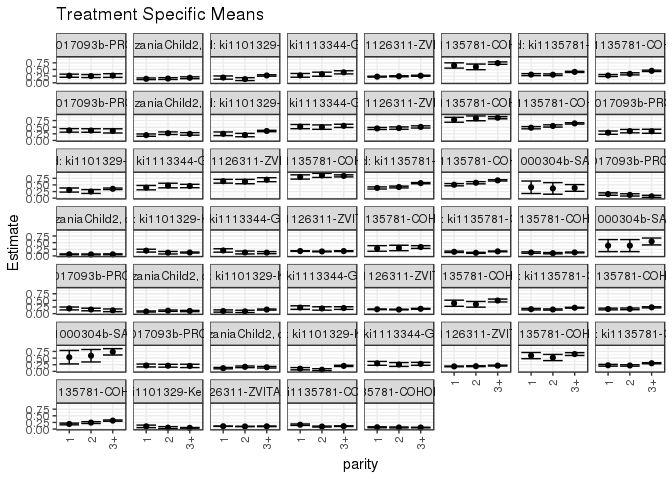

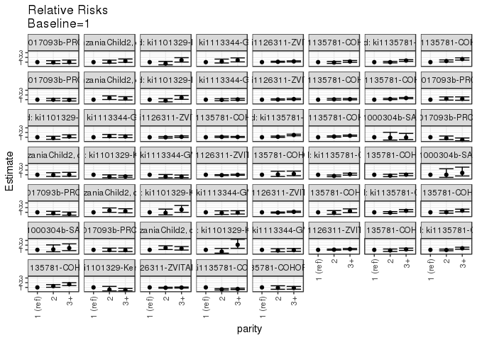

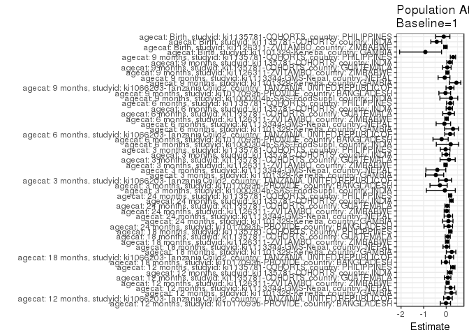

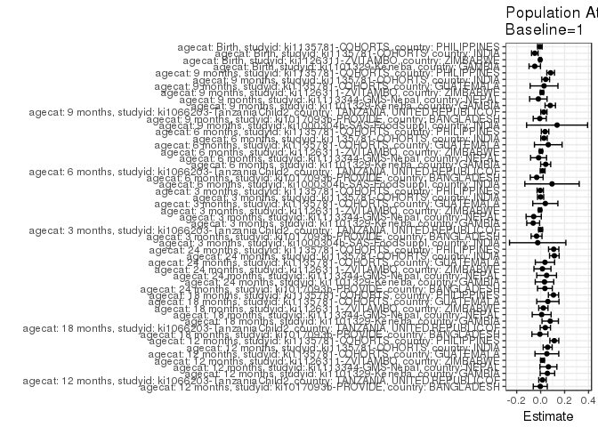

## Results Table

### Parameter: TSM

| agecat | studyid | country | intervention_level | baseline_level | estimate | ci_lower | ci_upper |
| --- | --- | --- | --- | --- | --- | --- | --- |
| Birth | ki1101329-Keneba | GAMBIA | 1 | NA | 0.1025641 | 0.0549386 | 0.1501896 |
| Birth | ki1101329-Keneba | GAMBIA | 2 | NA | 0.0547945 | 0.0178664 | 0.0917227 |
| Birth | ki1101329-Keneba | GAMBIA | 3+ | NA | 0.0461538 | 0.0337783 | 0.0585294 |
| Birth | ki1126311-ZVITAMBO | ZIMBABWE | 1 | NA | 0.1071668 | 0.0993213 | 0.1150123 |
| Birth | ki1126311-ZVITAMBO | ZIMBABWE | 2 | NA | 0.0986667 | 0.0895659 | 0.1077675 |
| Birth | ki1126311-ZVITAMBO | ZIMBABWE | 3+ | NA | 0.1031618 | 0.0934027 | 0.1129209 |
| Birth | ki1135781-COHORTS | INDIA | 1 | NA | 0.1637931 | 0.1362951 | 0.1912911 |
| Birth | ki1135781-COHORTS | INDIA | 2 | NA | 0.0945034 | 0.0766969 | 0.1123099 |
| Birth | ki1135781-COHORTS | INDIA | 3+ | NA | 0.1100879 | 0.0975352 | 0.1226406 |
| Birth | ki1135781-COHORTS | PHILIPPINES | 1 | NA | 0.0681481 | 0.0491344 | 0.0871619 |
| Birth | ki1135781-COHORTS | PHILIPPINES | 2 | NA | 0.0611354 | 0.0432174 | 0.0790533 |
| Birth | ki1135781-COHORTS | PHILIPPINES | 3+ | NA | 0.0586493 | 0.0474384 | 0.0698602 |
| 3 months | ki1000304b-SAS-FoodSuppl | INDIA | 1 | NA | 0.4117647 | 0.1765463 | 0.6469831 |
| 3 months | ki1000304b-SAS-FoodSuppl | INDIA | 2 | NA | 0.3684211 | 0.1503465 | 0.5864956 |
| 3 months | ki1000304b-SAS-FoodSuppl | INDIA | 3+ | NA | 0.3859649 | 0.2588991 | 0.5130307 |
| 3 months | ki1017093b-PROVIDE | BANGLADESH | 1 | NA | 0.1551020 | 0.1097379 | 0.2004662 |
| 3 months | ki1017093b-PROVIDE | BANGLADESH | 2 | NA | 0.1233480 | 0.0805374 | 0.1661587 |
| 3 months | ki1017093b-PROVIDE | BANGLADESH | 3+ | NA | 0.0693642 | 0.0314746 | 0.1072537 |
| 3 months | ki1066203-TanzaniaChild2 | TANZANIA, UNITED REPUBLIC OF | 1 | NA | 0.0592686 | 0.0428305 | 0.0757067 |
| 3 months | ki1066203-TanzaniaChild2 | TANZANIA, UNITED REPUBLIC OF | 2 | NA | 0.0567568 | 0.0400824 | 0.0734311 |
| 3 months | ki1066203-TanzaniaChild2 | TANZANIA, UNITED REPUBLIC OF | 3+ | NA | 0.0602740 | 0.0430057 | 0.0775422 |
| 3 months | ki1101329-Keneba | GAMBIA | 1 | NA | 0.1981132 | 0.1444444 | 0.2517820 |
| 3 months | ki1101329-Keneba | GAMBIA | 2 | NA | 0.1208791 | 0.0735050 | 0.1682532 |
| 3 months | ki1101329-Keneba | GAMBIA | 3+ | NA | 0.1274131 | 0.1092474 | 0.1455789 |
| 3 months | ki1113344-GMS-Nepal | NEPAL | 1 | NA | 0.2051282 | 0.1417080 | 0.2685484 |
| 3 months | ki1113344-GMS-Nepal | NEPAL | 2 | NA | 0.1283784 | 0.0744388 | 0.1823180 |
| 3 months | ki1113344-GMS-Nepal | NEPAL | 3+ | NA | 0.1235955 | 0.0840837 | 0.1631073 |
| 3 months | ki1126311-ZVITAMBO | ZIMBABWE | 1 | NA | 0.1832561 | 0.1707336 | 0.1957785 |
| 3 months | ki1126311-ZVITAMBO | ZIMBABWE | 2 | NA | 0.1677328 | 0.1539273 | 0.1815382 |
| 3 months | ki1126311-ZVITAMBO | ZIMBABWE | 3+ | NA | 0.1818517 | 0.1673312 | 0.1963722 |

[output cut: 129 more lines]

### Parameter: E(Y)

| agecat | studyid | country | intervention_level | baseline_level | estimate | ci_lower | ci_upper |
| --- | --- | --- | --- | --- | --- | --- | --- |
| Birth | ki1101329-Keneba | GAMBIA | NA | NA | 0.0533049 | 0.0523854 | 0.0542244 |
| Birth | ki1126311-ZVITAMBO | ZIMBABWE | NA | NA | 0.1035505 | 0.1034909 | 0.1036101 |
| Birth | ki1135781-COHORTS | INDIA | NA | NA | 0.1152353 | 0.1145380 | 0.1159326 |
| Birth | ki1135781-COHORTS | PHILIPPINES | NA | NA | 0.0613115 | 0.0611774 | 0.0614456 |
| 3 months | ki1000304b-SAS-FoodSuppl | INDIA | NA | NA | 0.3870968 | 0.3843304 | 0.3898631 |
| 3 months | ki1017093b-PROVIDE | BANGLADESH | NA | NA | 0.1209302 | 0.1183011 | 0.1235594 |
| 3 months | ki1066203-TanzaniaChild2 | TANZANIA, UNITED REPUBLIC OF | NA | NA | 0.0587715 | 0.0587112 | 0.0588319 |
| 3 months | ki1101329-Keneba | GAMBIA | NA | NA | 0.1355832 | 0.1344490 | 0.1367174 |
| 3 months | ki1113344-GMS-Nepal | NEPAL | NA | NA | 0.1471103 | 0.1441857 | 0.1500349 |
| 3 months | ki1126311-ZVITAMBO | ZIMBABWE | NA | NA | 0.1780896 | 0.1779485 | 0.1782308 |
| 3 months | ki1135781-COHORTS | GUATEMALA | NA | NA | 0.3206751 | 0.3187959 | 0.3225543 |
| 3 months | ki1135781-COHORTS | INDIA | NA | NA | 0.1537054 | 0.1530231 | 0.1543877 |
| 3 months | ki1135781-COHORTS | PHILIPPINES | NA | NA | 0.1234783 | 0.1230775 | 0.1238790 |
| 6 months | ki1000304b-SAS-FoodSuppl | INDIA | NA | NA | 0.4838710 | 0.4684465 | 0.4992954 |
| 6 months | ki1017093b-PROVIDE | BANGLADESH | NA | NA | 0.1612350 | 0.1589841 | 0.1634859 |
| 6 months | ki1066203-TanzaniaChild2 | TANZANIA, UNITED REPUBLIC OF | NA | NA | 0.0965000 | 0.0959352 | 0.0970648 |
| 6 months | ki1101329-Keneba | GAMBIA | NA | NA | 0.1398645 | 0.1386216 | 0.1411073 |
| 6 months | ki1113344-GMS-Nepal | NEPAL | NA | NA | 0.2113677 | 0.2103334 | 0.2124020 |
| 6 months | ki1126311-ZVITAMBO | ZIMBABWE | NA | NA | 0.1662648 | 0.1660310 | 0.1664986 |
| 6 months | ki1135781-COHORTS | GUATEMALA | NA | NA | 0.4547414 | 0.4494011 | 0.4600817 |
| 6 months | ki1135781-COHORTS | INDIA | NA | NA | 0.1957586 | 0.1948439 | 0.1966732 |
| 6 months | ki1135781-COHORTS | PHILIPPINES | NA | NA | 0.2112260 | 0.2100947 | 0.2123573 |
| 9 months | ki1000304b-SAS-FoodSuppl | INDIA | NA | NA | 0.6705882 | 0.6522713 | 0.6889052 |
| 9 months | ki1017093b-PROVIDE | BANGLADESH | NA | NA | 0.2132231 | 0.2127213 | 0.2137250 |
| 9 months | ki1066203-TanzaniaChild2 | TANZANIA, UNITED REPUBLIC OF | NA | NA | 0.1479592 | 0.1469854 | 0.1489330 |
| 9 months | ki1101329-Keneba | GAMBIA | NA | NA | 0.1790769 | 0.1765691 | 0.1815848 |
| 9 months | ki1113344-GMS-Nepal | NEPAL | NA | NA | 0.2813067 | 0.2800212 | 0.2825922 |
| 9 months | ki1126311-ZVITAMBO | ZIMBABWE | NA | NA | 0.1979411 | 0.1976602 | 0.1982220 |
| 9 months | ki1135781-COHORTS | GUATEMALA | NA | NA | 0.6225166 | 0.6180722 | 0.6269609 |
| 9 months | ki1135781-COHORTS | INDIA | NA | NA | 0.2711595 | 0.2698814 | 0.2724375 |
| 9 months | ki1135781-COHORTS | PHILIPPINES | NA | NA | 0.2750737 | 0.2730857 | 0.2770618 |
| 12 months | ki1017093b-PROVIDE | BANGLADESH | NA | NA | 0.2616667 | 0.2610628 | 0.2622706 |
| 12 months | ki1066203-TanzaniaChild2 | TANZANIA, UNITED REPUBLIC OF | NA | NA | 0.1638537 | 0.1629918 | 0.1647156 |
| 12 months | ki1101329-Keneba | GAMBIA | NA | NA | 0.2516340 | 0.2493516 | 0.2539164 |
| 12 months | ki1113344-GMS-Nepal | NEPAL | NA | NA | 0.3422939 | 0.3382037 | 0.3463841 |
| 12 months | ki1126311-ZVITAMBO | ZIMBABWE | NA | NA | 0.2445169 | 0.2441723 | 0.2448614 |
| 12 months | ki1135781-COHORTS | GUATEMALA | NA | NA | 0.7035647 | 0.6988364 | 0.7082931 |
| 12 months | ki1135781-COHORTS | INDIA | NA | NA | 0.3648609 | 0.3631291 | 0.3665927 |
| 12 months | ki1135781-COHORTS | PHILIPPINES | NA | NA | 0.3868472 | 0.3839728 | 0.3897216 |
| 18 months | ki1017093b-PROVIDE | BANGLADESH | NA | NA | 0.3731884 | 0.3725748 | 0.3738020 |
| 18 months | ki1066203-TanzaniaChild2 | TANZANIA, UNITED REPUBLIC OF | NA | NA | 0.2401656 | 0.2382507 | 0.2420806 |
| 18 months | ki1101329-Keneba | GAMBIA | NA | NA | 0.3313878 | 0.3287603 | 0.3340153 |
| 18 months | ki1113344-GMS-Nepal | NEPAL | NA | NA | 0.5309091 | 0.5292334 | 0.5325848 |
| 18 months | ki1126311-ZVITAMBO | ZIMBABWE | NA | NA | 0.4757168 | 0.4745631 | 0.4768704 |
| 18 months | ki1135781-COHORTS | GUATEMALA | NA | NA | 0.8394495 | 0.8367175 | 0.8421816 |
| 18 months | ki1135781-COHORTS | PHILIPPINES | NA | NA | 0.5874799 | 0.5848205 | 0.5901394 |
| 24 months | ki1017093b-PROVIDE | BANGLADESH | NA | NA | 0.3292894 | 0.3270836 | 0.3314952 |
| 24 months | ki1101329-Keneba | GAMBIA | NA | NA | 0.3386628 | 0.3369549 | 0.3403706 |
| 24 months | ki1113344-GMS-Nepal | NEPAL | NA | NA | 0.4468938 | 0.4441404 | 0.4496472 |
| 24 months | ki1126311-ZVITAMBO | ZIMBABWE | NA | NA | 0.6535088 | 0.6507736 | 0.6562440 |
| 24 months | ki1135781-COHORTS | GUATEMALA | NA | NA | 0.8359073 | 0.8343388 | 0.8374759 |
| 24 months | ki1135781-COHORTS | INDIA | NA | NA | 0.5001478 | 0.4974612 | 0.5028344 |
| 24 months | ki1135781-COHORTS | PHILIPPINES | NA | NA | 0.6167689 | 0.6141055 | 0.6194323 |

### Parameter: RR

| agecat | studyid | country | intervention_level | baseline_level | estimate | ci_lower | ci_upper |
| --- | --- | --- | --- | --- | --- | --- | --- |
| Birth | ki1101329-Keneba | GAMBIA | 1 | 1 | 1.0000000 | 1.0000000 | 1.0000000 |
| Birth | ki1101329-Keneba | GAMBIA | 2 | 1 | 0.5342466 | 0.2356709 | 1.2110933 |
| Birth | ki1101329-Keneba | GAMBIA | 3+ | 1 | 0.4500000 | 0.2632335 | 0.7692791 |
| Birth | ki1126311-ZVITAMBO | ZIMBABWE | 1 | 1 | 1.0000000 | 1.0000000 | 1.0000000 |
| Birth | ki1126311-ZVITAMBO | ZIMBABWE | 2 | 1 | 0.9206833 | 0.8184046 | 1.0357442 |
| Birth | ki1126311-ZVITAMBO | ZIMBABWE | 3+ | 1 | 0.9626290 | 0.8541012 | 1.0849470 |
| Birth | ki1135781-COHORTS | INDIA | 1 | 1 | 1.0000000 | 1.0000000 | 1.0000000 |
| Birth | ki1135781-COHORTS | INDIA | 2 | 1 | 0.5769680 | 0.4482824 | 0.7425945 |
| Birth | ki1135781-COHORTS | INDIA | 3+ | 1 | 0.6721156 | 0.5486645 | 0.8233437 |
| Birth | ki1135781-COHORTS | PHILIPPINES | 1 | 1 | 1.0000000 | 1.0000000 | 1.0000000 |
| Birth | ki1135781-COHORTS | PHILIPPINES | 2 | 1 | 0.8970951 | 0.5985491 | 1.3445507 |
| Birth | ki1135781-COHORTS | PHILIPPINES | 3+ | 1 | 0.8606146 | 0.6136598 | 1.2069511 |
| 3 months | ki1000304b-SAS-FoodSuppl | INDIA | 1 | 1 | 1.0000000 | 1.0000000 | 1.0000000 |
| 3 months | ki1000304b-SAS-FoodSuppl | INDIA | 2 | 1 | 0.8947368 | 0.3930436 | 2.0368071 |
| 3 months | ki1000304b-SAS-FoodSuppl | INDIA | 3+ | 1 | 0.9373434 | 0.4847964 | 1.8123330 |
| 3 months | ki1017093b-PROVIDE | BANGLADESH | 1 | 1 | 1.0000000 | 1.0000000 | 1.0000000 |
| 3 months | ki1017093b-PROVIDE | BANGLADESH | 2 | 1 | 0.7952701 | 0.5051251 | 1.2520752 |
| 3 months | ki1017093b-PROVIDE | BANGLADESH | 3+ | 1 | 0.4472163 | 0.2406700 | 0.8310234 |
| 3 months | ki1066203-TanzaniaChild2 | TANZANIA, UNITED REPUBLIC OF | 1 | 1 | 1.0000000 | 1.0000000 | 1.0000000 |
| 3 months | ki1066203-TanzaniaChild2 | TANZANIA, UNITED REPUBLIC OF | 2 | 1 | 0.9576193 | 0.6393353 | 1.4343566 |
| 3 months | ki1066203-TanzaniaChild2 | TANZANIA, UNITED REPUBLIC OF | 3+ | 1 | 1.0169630 | 0.6825422 | 1.5152377 |
| 3 months | ki1101329-Keneba | GAMBIA | 1 | 1 | 1.0000000 | 1.0000000 | 1.0000000 |
| 3 months | ki1101329-Keneba | GAMBIA | 2 | 1 | 0.6101518 | 0.3789033 | 0.9825335 |
| 3 months | ki1101329-Keneba | GAMBIA | 3+ | 1 | 0.6431329 | 0.4735342 | 0.8734743 |
| 3 months | ki1113344-GMS-Nepal | NEPAL | 1 | 1 | 1.0000000 | 1.0000000 | 1.0000000 |
| 3 months | ki1113344-GMS-Nepal | NEPAL | 2 | 1 | 0.6258446 | 0.3714623 | 1.0544313 |
| 3 months | ki1113344-GMS-Nepal | NEPAL | 3+ | 1 | 0.6025281 | 0.3862177 | 0.9399883 |
| 3 months | ki1126311-ZVITAMBO | ZIMBABWE | 1 | 1 | 1.0000000 | 1.0000000 | 1.0000000 |
| 3 months | ki1126311-ZVITAMBO | ZIMBABWE | 2 | 1 | 0.9152917 | 0.8224335 | 1.0186342 |
| 3 months | ki1126311-ZVITAMBO | ZIMBABWE | 3+ | 1 | 0.9923367 | 0.8933396 | 1.1023043 |

[output cut: 129 more lines]

### Parameter: PAR

| agecat | studyid | country | intervention_level | baseline_level | estimate | ci_lower | ci_upper |
| --- | --- | --- | --- | --- | --- | --- | --- |
| Birth | ki1101329-Keneba | GAMBIA | 1 | NA | -0.0492592 | -0.0968936 | -0.0016248 |
| Birth | ki1126311-ZVITAMBO | ZIMBABWE | 1 | NA | -0.0036163 | -0.0114620 | 0.0042294 |
| Birth | ki1135781-COHORTS | INDIA | 1 | NA | -0.0485578 | -0.0760646 | -0.0210510 |
| Birth | ki1135781-COHORTS | PHILIPPINES | 1 | NA | -0.0068367 | -0.0258509 | 0.0121776 |
| 3 months | ki1000304b-SAS-FoodSuppl | INDIA | 1 | NA | -0.0246679 | -0.2599026 | 0.2105667 |
| 3 months | ki1017093b-PROVIDE | BANGLADESH | 1 | NA | -0.0341718 | -0.0796121 | 0.0112685 |
| 3 months | ki1066203-TanzaniaChild2 | TANZANIA, UNITED REPUBLIC OF | 1 | NA | -0.0004971 | -0.0169353 | 0.0159412 |
| 3 months | ki1101329-Keneba | GAMBIA | 1 | NA | -0.0625300 | -0.1162108 | -0.0088492 |
| 3 months | ki1113344-GMS-Nepal | NEPAL | 1 | NA | -0.0580179 | -0.1215055 | 0.0054697 |
| 3 months | ki1126311-ZVITAMBO | ZIMBABWE | 1 | NA | -0.0051664 | -0.0176896 | 0.0073568 |
| 3 months | ki1135781-COHORTS | GUATEMALA | 1 | NA | 0.0389850 | -0.0657735 | 0.1437434 |
| 3 months | ki1135781-COHORTS | INDIA | 1 | NA | -0.0003487 | -0.0263706 | 0.0256733 |
| 3 months | ki1135781-COHORTS | PHILIPPINES | 1 | NA | -0.0035576 | -0.0299058 | 0.0227906 |
| 6 months | ki1000304b-SAS-FoodSuppl | INDIA | 1 | NA | 0.0949821 | -0.1319718 | 0.3219359 |
| 6 months | ki1017093b-PROVIDE | BANGLADESH | 1 | NA | -0.0330778 | -0.0865587 | 0.0204031 |
| 6 months | ki1066203-TanzaniaChild2 | TANZANIA, UNITED REPUBLIC OF | 1 | NA | 0.0165000 | -0.0036103 | 0.0366103 |
| 6 months | ki1101329-Keneba | GAMBIA | 1 | NA | 0.0419263 | 0.0000694 | 0.0837832 |
| 6 months | ki1113344-GMS-Nepal | NEPAL | 1 | NA | -0.0173905 | -0.0840135 | 0.0492325 |
| 6 months | ki1126311-ZVITAMBO | ZIMBABWE | 1 | NA | 0.0024247 | -0.0102028 | 0.0150521 |
| 6 months | ki1135781-COHORTS | GUATEMALA | 1 | NA | 0.0634370 | -0.0519654 | 0.1788395 |
| 6 months | ki1135781-COHORTS | INDIA | 1 | NA | 0.0281910 | 0.0012631 | 0.0551189 |
| 6 months | ki1135781-COHORTS | PHILIPPINES | 1 | NA | 0.0370100 | 0.0059545 | 0.0680654 |
| 9 months | ki1000304b-SAS-FoodSuppl | INDIA | 1 | NA | 0.1372549 | -0.1173705 | 0.3918803 |
| 9 months | ki1017093b-PROVIDE | BANGLADESH | 1 | NA | -0.0074976 | -0.0621007 | 0.0471055 |
| 9 months | ki1066203-TanzaniaChild2 | TANZANIA, UNITED REPUBLIC OF | 1 | NA | 0.0269914 | 0.0012979 | 0.0526850 |
| 9 months | ki1101329-Keneba | GAMBIA | 1 | NA | 0.0801758 | 0.0367191 | 0.1236326 |
| 9 months | ki1113344-GMS-Nepal | NEPAL | 1 | NA | -0.0193469 | -0.0920820 | 0.0533882 |
| 9 months | ki1126311-ZVITAMBO | ZIMBABWE | 1 | NA | 0.0110774 | -0.0027715 | 0.0249263 |
| 9 months | ki1135781-COHORTS | GUATEMALA | 1 | NA | 0.0283137 | -0.0877627 | 0.1443900 |
| 9 months | ki1135781-COHORTS | INDIA | 1 | NA | 0.0420573 | 0.0096204 | 0.0744942 |
| 9 months | ki1135781-COHORTS | PHILIPPINES | 1 | NA | 0.0836944 | 0.0516118 | 0.1157770 |
| 12 months | ki1017093b-PROVIDE | BANGLADESH | 1 | NA | -0.0031735 | -0.0616652 | 0.0553182 |
| 12 months | ki1066203-TanzaniaChild2 | TANZANIA, UNITED REPUBLIC OF | 1 | NA | 0.0153389 | -0.0156993 | 0.0463770 |
| 12 months | ki1101329-Keneba | GAMBIA | 1 | NA | 0.0565120 | -0.0042026 | 0.1172267 |
| 12 months | ki1113344-GMS-Nepal | NEPAL | 1 | NA | 0.0648746 | -0.0057917 | 0.1355408 |
| 12 months | ki1126311-ZVITAMBO | ZIMBABWE | 1 | NA | 0.0154287 | -0.0005644 | 0.0314219 |
| 12 months | ki1135781-COHORTS | GUATEMALA | 1 | NA | 0.0518793 | -0.0473088 | 0.1510675 |
| 12 months | ki1135781-COHORTS | INDIA | 1 | NA | 0.0583541 | 0.0209161 | 0.0957920 |
| 12 months | ki1135781-COHORTS | PHILIPPINES | 1 | NA | 0.1142840 | 0.0770869 | 0.1514811 |
| 18 months | ki1017093b-PROVIDE | BANGLADESH | 1 | NA | -0.0061219 | -0.0729327 | 0.0606889 |
| 18 months | ki1066203-TanzaniaChild2 | TANZANIA, UNITED REPUBLIC OF | 1 | NA | 0.0389644 | -0.0041590 | 0.0820879 |
| 18 months | ki1101329-Keneba | GAMBIA | 1 | NA | 0.0797749 | 0.0113879 | 0.1481619 |
| 18 months | ki1113344-GMS-Nepal | NEPAL | 1 | NA | 0.0083284 | -0.0703947 | 0.0870516 |
| 18 months | ki1126311-ZVITAMBO | ZIMBABWE | 1 | NA | 0.0225918 | -0.0160033 | 0.0611869 |
| 18 months | ki1135781-COHORTS | GUATEMALA | 1 | NA | 0.0602288 | -0.0325608 | 0.1530183 |
| 18 months | ki1135781-COHORTS | PHILIPPINES | 1 | NA | 0.1073287 | 0.0646629 | 0.1499945 |
| 24 months | ki1017093b-PROVIDE | BANGLADESH | 1 | NA | 0.0354506 | -0.0261052 | 0.0970064 |
| 24 months | ki1101329-Keneba | GAMBIA | 1 | NA | 0.0320934 | -0.0451600 | 0.1093469 |
| 24 months | ki1113344-GMS-Nepal | NEPAL | 1 | NA | 0.0498350 | -0.0325261 | 0.1321960 |
| 24 months | ki1126311-ZVITAMBO | ZIMBABWE | 1 | NA | 0.0150907 | -0.0558209 | 0.0860023 |
| 24 months | ki1135781-COHORTS | GUATEMALA | 1 | NA | 0.0359073 | -0.0446209 | 0.1164356 |
| 24 months | ki1135781-COHORTS | INDIA | 1 | NA | 0.1143071 | 0.0740722 | 0.1545420 |
| 24 months | ki1135781-COHORTS | PHILIPPINES | 1 | NA | 0.1091353 | 0.0662381 | 0.1520326 |

### Parameter: PAF

| agecat | studyid | country | intervention_level | baseline_level | estimate | ci_lower | ci_upper |
| --- | --- | --- | --- | --- | --- | --- | --- |
| Birth | ki1101329-Keneba | GAMBIA | 1 | NA | -0.9241025 | -2.0621846 | -0.2089965 |
| Birth | ki1126311-ZVITAMBO | ZIMBABWE | 1 | NA | -0.0349227 | -0.1135322 | 0.0381373 |
| Birth | ki1135781-COHORTS | INDIA | 1 | NA | -0.4213793 | -0.6813872 | -0.2015787 |
| Birth | ki1135781-COHORTS | PHILIPPINES | 1 | NA | -0.1115072 | -0.4692201 | 0.1591128 |
| 3 months | ki1000304b-SAS-FoodSuppl | INDIA | 1 | NA | -0.0637255 | -0.8833776 | 0.3992113 |
| 3 months | ki1017093b-PROVIDE | BANGLADESH | 1 | NA | -0.2825746 | -0.7197102 | 0.0434449 |
| 3 months | ki1066203-TanzaniaChild2 | TANZANIA, UNITED REPUBLIC OF | 1 | NA | -0.0084575 | -0.3307912 | 0.2358032 |
| 3 months | ki1101329-Keneba | GAMBIA | 1 | NA | -0.4611930 | -0.9160813 | -0.1142978 |
| 3 months | ki1113344-GMS-Nepal | NEPAL | 1 | NA | -0.3943834 | -0.9007800 | -0.0228985 |
| 3 months | ki1126311-ZVITAMBO | ZIMBABWE | 1 | NA | -0.0290102 | -0.1017887 | 0.0389608 |
| 3 months | ki1135781-COHORTS | GUATEMALA | 1 | NA | 0.1215715 | -0.2741230 | 0.3943783 |
| 3 months | ki1135781-COHORTS | INDIA | 1 | NA | -0.0022683 | -0.1867045 | 0.1535030 |
| 3 months | ki1135781-COHORTS | PHILIPPINES | 1 | NA | -0.0288113 | -0.2659377 | 0.1638983 |
| 6 months | ki1000304b-SAS-FoodSuppl | INDIA | 1 | NA | 0.1962963 | -0.4399288 | 0.5514086 |
| 6 months | ki1017093b-PROVIDE | BANGLADESH | 1 | NA | -0.2051528 | -0.5871620 | 0.0849118 |
| 6 months | ki1066203-TanzaniaChild2 | TANZANIA, UNITED REPUBLIC OF | 1 | NA | 0.1709845 | -0.0659123 | 0.3552314 |
| 6 months | ki1101329-Keneba | GAMBIA | 1 | NA | 0.2997638 | -0.0735243 | 0.5432514 |
| 6 months | ki1113344-GMS-Nepal | NEPAL | 1 | NA | -0.0822760 | -0.4481836 | 0.1911789 |
| 6 months | ki1126311-ZVITAMBO | ZIMBABWE | 1 | NA | 0.0145832 | -0.0643675 | 0.0876776 |
| 6 months | ki1135781-COHORTS | GUATEMALA | 1 | NA | 0.1395013 | -0.1555682 | 0.3592261 |
| 6 months | ki1135781-COHORTS | INDIA | 1 | NA | 0.1440090 | -0.0051922 | 0.2710642 |
| 6 months | ki1135781-COHORTS | PHILIPPINES | 1 | NA | 0.1752150 | 0.0143087 | 0.3098547 |
| 9 months | ki1000304b-SAS-FoodSuppl | INDIA | 1 | NA | 0.2046784 | -0.2814084 | 0.5063740 |
| 9 months | ki1017093b-PROVIDE | BANGLADESH | 1 | NA | -0.0351631 | -0.3257060 | 0.1917042 |
| 9 months | ki1066203-TanzaniaChild2 | TANZANIA, UNITED REPUBLIC OF | 1 | NA | 0.1824249 | -0.0109972 | 0.3388419 |
| 9 months | ki1101329-Keneba | GAMBIA | 1 | NA | 0.4477172 | 0.1434203 | 0.6439138 |
| 9 months | ki1113344-GMS-Nepal | NEPAL | 1 | NA | -0.0687750 | -0.3613023 | 0.1608917 |
| 9 months | ki1126311-ZVITAMBO | ZIMBABWE | 1 | NA | 0.0559631 | -0.0166581 | 0.1233968 |
| 9 months | ki1135781-COHORTS | GUATEMALA | 1 | NA | 0.0454826 | -0.1604246 | 0.2148533 |
| 9 months | ki1135781-COHORTS | INDIA | 1 | NA | 0.1551017 | 0.0266267 | 0.2666193 |
| 9 months | ki1135781-COHORTS | PHILIPPINES | 1 | NA | 0.3042618 | 0.1774197 | 0.4115448 |
| 12 months | ki1017093b-PROVIDE | BANGLADESH | 1 | NA | -0.0121281 | -0.2622704 | 0.1884439 |
| 12 months | ki1066203-TanzaniaChild2 | TANZANIA, UNITED REPUBLIC OF | 1 | NA | 0.0936132 | -0.1170450 | 0.2645444 |
| 12 months | ki1101329-Keneba | GAMBIA | 1 | NA | 0.2245803 | -0.0583636 | 0.4318817 |
| 12 months | ki1113344-GMS-Nepal | NEPAL | 1 | NA | 0.1895288 | -0.0454435 | 0.3716891 |
| 12 months | ki1126311-ZVITAMBO | ZIMBABWE | 1 | NA | 0.0630988 | -0.0046436 | 0.1262734 |
| 12 months | ki1135781-COHORTS | GUATEMALA | 1 | NA | 0.0737378 | -0.0785095 | 0.2044932 |
| 12 months | ki1135781-COHORTS | INDIA | 1 | NA | 0.1599351 | 0.0508332 | 0.2564962 |
| 12 months | ki1135781-COHORTS | PHILIPPINES | 1 | NA | 0.2954242 | 0.1925654 | 0.3851798 |
| 18 months | ki1017093b-PROVIDE | BANGLADESH | 1 | NA | -0.0164044 | -0.2121664 | 0.1477425 |
| 18 months | ki1066203-TanzaniaChild2 | TANZANIA, UNITED REPUBLIC OF | 1 | NA | 0.1622398 | -0.0379458 | 0.3238162 |
| 18 months | ki1101329-Keneba | GAMBIA | 1 | NA | 0.2407298 | 0.0036812 | 0.4213787 |
| 18 months | ki1113344-GMS-Nepal | NEPAL | 1 | NA | 0.0156871 | -0.1443428 | 0.1533378 |
| 18 months | ki1126311-ZVITAMBO | ZIMBABWE | 1 | NA | 0.0474900 | -0.0371922 | 0.1252583 |
| 18 months | ki1135781-COHORTS | GUATEMALA | 1 | NA | 0.0717479 | -0.0456313 | 0.1759505 |
| 18 months | ki1135781-COHORTS | PHILIPPINES | 1 | NA | 0.1826934 | 0.1067950 | 0.2521425 |
| 24 months | ki1017093b-PROVIDE | BANGLADESH | 1 | NA | 0.1076578 | -0.1002697 | 0.2762914 |
| 24 months | ki1101329-Keneba | GAMBIA | 1 | NA | 0.0947652 | -0.1646507 | 0.2963985 |
| 24 months | ki1113344-GMS-Nepal | NEPAL | 1 | NA | 0.1115141 | -0.0932632 | 0.2779349 |
| 24 months | ki1126311-ZVITAMBO | ZIMBABWE | 1 | NA | 0.0230918 | -0.0916689 | 0.1257884 |
| 24 months | ki1135781-COHORTS | GUATEMALA | 1 | NA | 0.0429561 | -0.0583940 | 0.1346011 |
| 24 months | ki1135781-COHORTS | INDIA | 1 | NA | 0.2285466 | 0.1438371 | 0.3048749 |
| 24 months | ki1135781-COHORTS | PHILIPPINES | 1 | NA | 0.1769469 | 0.1044191 | 0.2436010 |